# IMT 573 - Lab 1 - Basic Data Analysis

### Instructions

Before beginning this assignment, please ensure you have access to a working instance of Jupyter Notebooks with Python 3.

1. First, replace the “YOUR NAME HERE” text in the next cell with your own full name. Any collaborators must also be listed in this cell.
2. Be sure to include well-documented (e.g. commented) code cells, figures, and clearly written text explanations as necessary. Any figures should be clearly labeled and appropriately referenced within the text. Be sure that each visualization adds value to your written explanation; avoid redundancy – you do no need four different visualizations of the same pattern.
3. Collaboration on problem sets and labs is fun, useful, and encouraged. However, each student must turn in an individual write-up in their own words as well as code/work that is their own. Regardless of whether you work with others, what you turn in must be your own work; this includes code and interpretation of results. The names of all collaborators must be listed on each assignment. Do not copy-and-paste from other students’ responses or code - your code should never be on any other student's screen or machine.
4. All materials and resources that you use (with the exception of lecture slides) must be appropriately referenced within your assignment.

Name: Pratiibh Bassi

Collaborators:

### Problem 1: Loading and inspecting data

In this lab, we will use the `faithful` data from the `pydatasets` package. Use this data to answer the following questions. The package is imported below - you may need to install the package if you're getting an error when importing.

Once the package is imported, the data is available by calling `data('faithful')` (note how `data` refers to the variable from `import`). Store the data in your variable of choice, keeping in mind that data from `pydatasets` is imported as pandas dataframes.

```python
pip install pydataset
```

[output not shown]

```python
from pydataset import data
```

```
initiated datasets repo at: C:\Users\Pratiibh\.pydataset/
```

```python
faithful = data('faithful')
```

Of course, simply importing the data doesn't provide us much context on the data itself. Use the following call to print documentation of the dataset: `data('faithful', show_doc = True)`. This call will not import the data so do not store the result in a variable.

#### (a) Examine the data

What does the data represent? Where does the data come from? Provide your answer below.

```python
data('faithful')
```

|  | eruptions | waiting |
| --- | --- | --- |
| 1 | 3.600 | 79 |
| 2 | 1.800 | 54 |
| 3 | 3.333 | 74 |
| 4 | 2.283 | 62 |
| 5 | 4.533 | 85 |
| ... | ... | ... |
| 268 | 4.117 | 81 |
| 269 | 2.150 | 46 |
| 270 | 4.417 | 90 |
| 271 | 1.817 | 46 |
| 272 | 4.467 | 74 |

272 rows × 2 columns

```python
data('faithful', show_doc = True)
```

```
faithful

PyDataset Documentation (adopted from R Documentation. The displayed examples are in R)

## Old Faithful Geyser Data

### Description

Waiting time between eruptions and the duration of the eruption for the Old
Faithful geyser in Yellowstone National Park, Wyoming, USA.

### Usage

    faithful

### Format

A data frame with 272 observations on 2 variables.

[,1]

eruptions

numeric

Eruption time in mins

[,2]

waiting

numeric

Waiting time to next eruption (in mins)

### Details

A closer look at `faithful$eruptions` reveals that these are heavily rounded
times originally in seconds, where multiples of 5 are more frequent than
expected under non-human measurement. For a better version of the eruption
```

[output cut: 22 more lines]

```

    require(stats); require(graphics)
    f.tit <-  "faithful data: Eruptions of Old Faithful"
    ne60 <- round(e60 <- 60 * faithful$eruptions)
    all.equal(e60, ne60)             # relative diff. ~ 1/10000
    table(zapsmall(abs(e60 - ne60))) # 0, 0.02 or 0.04
    faithful$better.eruptions <- ne60 / 60
    te <- table(ne60)
    te[te >= 4]                      # (too) many multiples of 5 !
    plot(names(te), te, type = "h", main = f.tit, xlab = "Eruption time (sec)")
    plot(faithful[, -3], main = f.tit,
         xlab = "Eruption time (min)",
         ylab = "Waiting time to next eruption (min)")
    lines(lowess(faithful$eruptions, faithful$waiting, f = 2/3, iter = 3),
          col = "red")
```

The data represents Old Faithful geyser data. The data is built in with the pydatasets package, which needs to be installed in order to see or use the data.

#### (b) Data types

What data type is used to store this data? What is the type of each column?

```python
type(faithful)
```

```
pandas.core.frame.DataFrame
```

Variable type is dataframes.

#### (c) Variables

What are the variables in this dataset? Describe what each variable measures.

```python
faithful.dtypes
```

```
eruptions    float64
waiting        int64
dtype: object
```

The variables in the dataset are "eruptions" and "waiting". "eruptions" measures the time of the eruption itself at Old Faithful Geyser and "waiting" measures the time spent in between eruptions. Both variables are measured in minutes. "eruptions" is a float while "waiting" is an int.

### Problem 2: Basic computation

Continue to use the faithful data to answer these specific questions.

#### (a) Basic statistics

What is the average, or mean, waiting time between eruptions?

```python
faithful['waiting'].mean()
```

```
70.8970588235294
```

The average waiting time in minutes between eruptions is 70.897 (rounded) minutes.

#### (b) Shortest time

What is the shortest time between eruptions that was observed?

```python
faithful['waiting'].min()
```

```
43
```

The shortest waiting time between eruptions (meaning the 'waiting' variable will be used) was 43 minutes.

#### (c) Longest eruption

What was the longest eruption observed?

```python
faithful['eruptions'].max()
```

```
5.1
```

The longest eruption observed was 5.1 minutes long.

### Problem 3: Visualization

Create a basic visualization of either the distribution of eruption times or waiting time between eruptions, your choice. You can use the `seaborn` package imported below. Again, if you encounter an error when importing the package, you may need to install the package. Be sure to label axes and add a title to the visualization. Hint: Use [seaborn's `histplot()`](https://seaborn.pydata.org/generated/seaborn.histplot.html) function on a single column of the data to start off. Use [`axes.set()`](https://matplotlib.org/stable/api/_as_gen/matplotlib.axes.Axes.set.html) to set the `x`, `y`, and `title` of the visualization.

```python
pip install seaborn
```

```python
import seaborn as sns
```

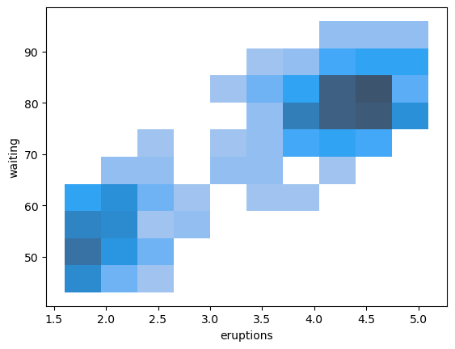

```python
sns.histplot(data=faithful, x='eruptions', y='waiting')
```

Couldn't figure out how to use axes.set but this is the histplot from seaborn of our data.